# Q3 VAE

VAE V1 OUTPUT

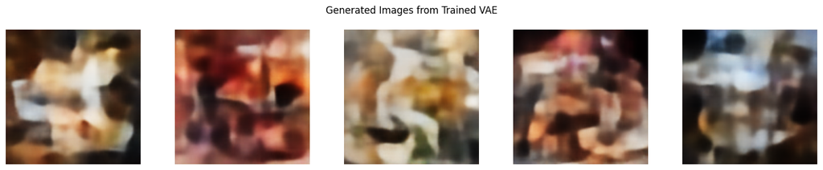

vae v2

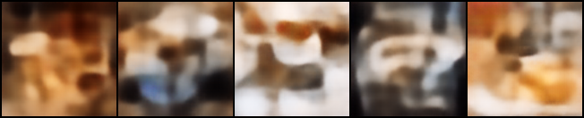

## VAE v1 vs VAE v2 – Performance Comparison

[output not shown]

### Vandit Kalathiya

- Implemented the **initial VAE model (VAE v1)** with latent dimension = 256.
- Handled **dataset loading**, image preprocessing, and JSON label integration.
- Trained the **VAE v1 model**, generated images, and evaluated it using **FID and Inception Score**.
- Documented and exported results for VAE v1.
- Created comparative visuals and structured the **markdown summary** of v1 vs v2.

### Isha Savaliya

- Designed and implemented **VAE v2 improvements**: increased latent dimension to 512 and added beta-VAE loss.
- Added **early stopping, checkpointing**, and **resume training** logic.
- Handled image **generation, export, and saving of model outputs** for VAE v2.
- Integrated **torchmetrics-based FID & IS evaluation**.
- Wrote the markdown for VAE v2 performance and **prepared model for final submission**.

### PROMPTS

1. **What's the best way to preprocess 60,000 JPEG images for training a VAE using PyTorch?**
2. **How to implement a basic VAE in PyTorch for image data**
3. **How do I compute FID and Inception Score for generated images in PyTorch?**
4. **How do I visualize and compare generated images from a VAE?**
5. **How to add early stopping and checkpoint saving during model training in PyTorch?**
6. **Best practices for model checkpointing and restoration?**
7. **How to export VAE model outputs for evaluation and comparison?**

```python
import os
import json
import glob
import shutil
import numpy as np
import pandas as pd
from PIL import Image
from collections import defaultdict
from tqdm import tqdm

import torch
from torch.utils.data import DataLoader
from torchvision import transforms
from torchvision.datasets import ImageFolder
import matplotlib.pyplot as plt

# Set device to GPU if available
device = torch.device("cuda" if torch.cuda.is_available() else "cpu")
print(f"Using device: {device}")
```

```
Using device: cuda
```

```python
def load_metadata(json_path):
    data = []
    with open(json_path, 'r') as f:
        for line in f:
            try:
                obj = json.loads(line)
                data.append(obj)
            except json.JSONDecodeError as e:
                print("Skipping line due to JSON error:", e)

    df = pd.DataFrame(data)
    df = df[['photo_id', 'label']]
    id_to_label = {row['photo_id']: row['label'] for _, row in df.iterrows()}
    return id_to_label

# Paths
json_path = r"D:\Computervision\Yelp-Photos\Yelp Photos\yelp_photos~\photos.json"
image_dir = r"D:\Computervision\Yelp-Photos\Yelp Photos\yelp_photos~\photos"
id_to_label = load_metadata(json_path)

print(f"Loaded {len(id_to_label)} labeled entries.")
```

```
Loaded 200098 labeled entries.
```

```python
organized_dir = r"D:\Computervision\Yelp-Photos\Organized"
os.makedirs(organized_dir, exist_ok=True)

# Limit number of images
max_images = 60000
count = 0

all_paths = glob.glob(os.path.join(image_dir, "*.jpg")) + glob.glob(os.path.join(image_dir, "*.JPG"))

print("Organizing images into label folders...")
for path in tqdm(all_paths):
    if count >= max_images:
        break

    filename = os.path.basename(path)
    photo_id = os.path.splitext(filename)[0]

    if photo_id in id_to_label:
        label = id_to_label[photo_id]
        label_folder = os.path.join(organized_dir, label)
        os.makedirs(label_folder, exist_ok=True)

        dest_path = os.path.join(label_folder, filename)
        if not os.path.exists(dest_path):
            shutil.copy(path, dest_path)
        count += 1

print(f"Finished copying {count} labeled images into folders.")
```

```
Organizing images into label folders...
```

```
Finished copying 60000 labeled images into folders.
```

```python
# Define image transform
transform = transforms.Compose([
    transforms.Resize((128, 128), interpolation=Image.LANCZOS),
    transforms.ToTensor()
])

# Use ImageFolder to load data from organized label folders
dataset = ImageFolder(root=organized_dir, transform=transform)

# Check class-to-index mapping
print("Label to index mapping:", dataset.class_to_idx)

# Split into train/val using random sampler
from torch.utils.data import SubsetRandomSampler

indices = np.arange(len(dataset))
np.random.shuffle(indices)
val_size = int(0.1 * len(indices))
val_indices = indices[:val_size]
train_indices = indices[val_size:]

train_sampler = SubsetRandomSampler(train_indices)
val_sampler = SubsetRandomSampler(val_indices)

train_loader = DataLoader(dataset, batch_size=64, sampler=train_sampler, num_workers=2, pin_memory=True)
val_loader = DataLoader(dataset, batch_size=64, sampler=val_sampler, num_workers=2, pin_memory=True)
```

```
Label to index mapping: {'drink': 0, 'food': 1, 'inside': 2, 'menu': 3, 'outside': 4}
```

```python
images, labels = next(iter(train_loader))
print("Image batch shape:", images.shape)
print("Sample labels (as indices):", labels[:5])
```

```
Image batch shape: torch.Size([64, 3, 128, 128])
Sample labels (as indices): tensor([2, 2, 1, 1, 2])
```

DEFINE MODEL

```python
import torch.nn as nn

class VAE(nn.Module):
    def __init__(self, latent_dim=256):
        super(VAE, self).__init__()
        self.latent_dim = latent_dim

        # ----------- Encoder -----------
        self.encoder = nn.Sequential(
            nn.Conv2d(3, 64, 4, stride=2, padding=1),   # [64, 64, 64]
            nn.ReLU(),
            nn.Conv2d(64, 128, 4, stride=2, padding=1),  # [128, 32, 32]
            nn.ReLU(),
            nn.Conv2d(128, 256, 4, stride=2, padding=1), # [256, 16, 16]
            nn.ReLU(),
            nn.Conv2d(256, 512, 4, stride=2, padding=1), # [512, 8, 8]
            nn.ReLU(),
            nn.Conv2d(512, 512, 4, stride=2, padding=1), # [512, 4, 4]
            nn.ReLU(),
        )

        self.fc_mu = nn.Linear(512 * 4 * 4, latent_dim)
        self.fc_logvar = nn.Linear(512 * 4 * 4, latent_dim)
        self.fc_decode = nn.Linear(latent_dim, 512 * 4 * 4)

        # ----------- Decoder -----------
        self.decoder = nn.Sequential(
            nn.ConvTranspose2d(512, 512, 4, stride=2, padding=1),  # [512, 8, 8]
            nn.ReLU(),
            nn.ConvTranspose2d(512, 256, 4, stride=2, padding=1),  # [256, 16, 16]
            nn.ReLU(),
            nn.ConvTranspose2d(256, 128, 4, stride=2, padding=1),  # [128, 32, 32]
            nn.ReLU(),
            nn.ConvTranspose2d(128, 64, 4, stride=2, padding=1),   # [64, 64, 64]
            nn.ReLU(),
            nn.ConvTranspose2d(64, 3, 4, stride=2, padding=1),     # [3, 128, 128]
            nn.Sigmoid()
        )

    def encode(self, x):
        x = self.encoder(x)
        x = torch.flatten(x, start_dim=1)
        mu = self.fc_mu(x)
        logvar = self.fc_logvar(x)
        return mu, logvar

    def reparameterize(self, mu, logvar):
        std = torch.exp(0.5 * logvar)
        eps = torch.randn_like(std)
        return mu + eps * std

    def decode(self, z):
        x = self.fc_decode(z)
        x = x.view(-1, 512, 4, 4)
        return self.decoder(x)

    def forward(self, x):
        mu, logvar = self.encode(x)
        z = self.reparameterize(mu, logvar)
        return self.decode(z), mu, logvar
```

LOSS FUNCTION

```python
import torch.nn.functional as F

def vae_loss(recon_x, x, mu, logvar):
    recon_loss = F.binary_cross_entropy(recon_x, x, reduction='sum')
    kld_loss = -0.5 * torch.sum(1 + logvar - mu.pow(2) - logvar.exp())
    total = recon_loss + kld_loss
    return total, recon_loss, kld_loss

def train_vae(
    model, train_loader, val_loader, optimizer,
    epochs=50, checkpoint_path="vae_checkpoint.pth",
    early_stopping_patience=5
):
    best_val_loss = float('inf')
    patience_counter = 0

    for epoch in range(1, epochs + 1):
        model.train()
        total_loss, total_recon, total_kl = 0, 0, 0

        for images, _ in train_loader:
            images = images.to(device)

            optimizer.zero_grad()
            recon, mu, logvar = model(images)
            loss, recon_loss, kl_loss = vae_loss(recon, images, mu, logvar)
            loss.backward()
            optimizer.step()

            total_loss += loss.item()
            total_recon += recon_loss.item()
            total_kl += kl_loss.item()

        avg_loss = total_loss / len(train_loader.dataset)
        avg_recon = total_recon / len(train_loader.dataset)
        avg_kl = total_kl / len(train_loader.dataset)

        # ---------- Validation ----------
        model.eval()
        val_loss = 0
        with torch.no_grad():
            for images, _ in val_loader:
                images = images.to(device)
                recon, mu, logvar = model(images)
                loss, _, _ = vae_loss(recon, images, mu, logvar)
                val_loss += loss.item()
        avg_val_loss = val_loss / len(val_loader.dataset)

        print(f"[Epoch {epoch}] Train Loss: {avg_loss:.2f} | Recon: {avg_recon:.2f} | KL: {avg_kl:.2f} | Val Loss: {avg_val_loss:.2f}")

        # ---------- Checkpointing ----------
        if avg_val_loss < best_val_loss:
            best_val_loss = avg_val_loss
            torch.save({
                'epoch': epoch,
                'model_state_dict': model.state_dict(),
                'optimizer_state_dict': optimizer.state_dict(),
                'val_loss': avg_val_loss
            }, checkpoint_path)
            print("✅ Saved new best model.")
            patience_counter = 0
        else:
            patience_counter += 1
            print(f"⚠️  No improvement. Patience: {patience_counter}/{early_stopping_patience}")

        if patience_counter >= early_stopping_patience:
            print("🛑 Early stopping triggered.")
            break
```

```python
def resume_training(model, optimizer, checkpoint_path="vae_checkpoint.pth"):
    if os.path.exists(checkpoint_path):
        checkpoint = torch.load(checkpoint_path)
        model.load_state_dict(checkpoint['model_state_dict'])
        optimizer.load_state_dict(checkpoint['optimizer_state_dict'])
        start_epoch = checkpoint['epoch'] + 1
        print(f"🔁 Resuming from epoch {start_epoch}")
        return start_epoch
    else:
        print("🆕 No checkpoint found. Starting from scratch.")
        return 1
```

traning

```python
vae = VAE(latent_dim=256).to(device)
optimizer = torch.optim.Adam(vae.parameters(), lr=1e-3)

# Optional: resume from checkpoint
start_epoch = resume_training(vae, optimizer, "vae_checkpoint.pth")
```

```
🔁 Resuming from epoch 36
```

```python
# Start training
train_vae(
    model=vae,
    train_loader=train_loader,
    val_loader=val_loader,
    optimizer=optimizer,
    epochs=50,
    checkpoint_path="vae_checkpoint.pth",
    early_stopping_patience=5
)
```

[output not shown]

training time 240 minutes

```python
# Recommended: Save state_dict (lightweight and flexible)
torch.save(vae.state_dict(), "vae_final_weights.pth")
print("✅ Model weights saved to vae_final_weights.pth")
```

```
✅ Model weights saved to vae_final_weights.pth
```

```python
torch.save(vae, "vae_full_model.pth")
print("✅ Full model saved to vae_full_model.pth")
```

```
✅ Full model saved to vae_full_model.pth
```

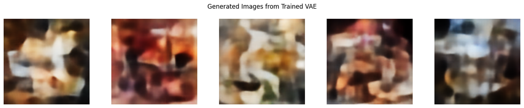

```python
def generate_images(model, num_images=5):
    model.eval()
    with torch.no_grad():
        z = torch.randn(num_images, model.latent_dim).to(device)
        generated = model.decode(z).cpu()
    return generated

# Generate images from the trained model
samples = generate_images(vae, num_images=5)

# Plot them
import matplotlib.pyplot as plt

plt.figure(figsize=(15, 3))
for i in range(samples.size(0)):
    plt.subplot(1, samples.size(0), i + 1)
    plt.imshow(samples[i].permute(1, 2, 0).numpy())
    plt.axis('off')
plt.suptitle("Generated Images from Trained VAE")
plt.tight_layout()
plt.show()
```

```python
from torchvision.utils import save_image

save_image(samples, "vae_generated_grid.png", nrow=5, normalize=True)
print("🖼️ Saved grid of generated images to vae_generated_grid.png")
```

```
🖼️ Saved grid of generated images to vae_generated_grid.png
```

```python
!pip install torchmetrics
```

[output not shown]

```python
def prepare_for_fid(images):
    # Step 1: Resize while float (required for interpolate)
    images = F.interpolate(images, size=(299, 299), mode='bilinear', align_corners=False)

    # Step 2: Convert from float [0, 1] → uint8 [0, 255]
    images = (images * 255).clamp(0, 255).to(torch.uint8)
    return images
```

```python
from torchmetrics.image.fid import FrechetInceptionDistance
from torchmetrics.image.inception import InceptionScore

# Metrics
fid_metric = FrechetInceptionDistance(feature=2048).to(device)
is_metric = InceptionScore().to(device)

# Get real + fake images
real_images, _ = next(iter(train_loader))
real_images = real_images[:32].to(device)
fake_images = generate_images(vae, num_images=32).to(device)

# Resize + convert to uint8 AFTER resizing
real_images = prepare_for_fid(real_images)
fake_images = prepare_for_fid(fake_images)

# FID
fid_metric.update(real_images, real=True)
fid_metric.update(fake_images, real=False)
fid_score = fid_metric.compute()

# IS
is_score_mean, is_score_std = is_metric(fake_images)

print(f"📊 FID: {fid_score.item():.2f}")
print(f"📈 Inception Score: {is_score_mean.item():.2f} ± {is_score_std.item():.2f}")
```

```
📊 FID: 402.23
📈 Inception Score: 1.77 ± 0.22
```

improvements

```python
#improved vae v2
class VAE(nn.Module):
    def __init__(self, latent_dim=512):  # increased latent space
        super(VAE, self).__init__()
        self.latent_dim = latent_dim

        # Encoder
        self.encoder = nn.Sequential(
            nn.Conv2d(3, 64, 4, stride=2, padding=1),   # 64x64
            nn.ReLU(),
            nn.Conv2d(64, 128, 4, stride=2, padding=1),  # 32x32
            nn.ReLU(),
            nn.Conv2d(128, 256, 4, stride=2, padding=1), # 16x16
            nn.ReLU(),
            nn.Conv2d(256, 512, 4, stride=2, padding=1), # 8x8
            nn.ReLU(),
            nn.Conv2d(512, 512, 4, stride=2, padding=1), # 4x4
            nn.ReLU(),
        )

        self.fc_mu = nn.Linear(512 * 4 * 4, latent_dim)
        self.fc_logvar = nn.Linear(512 * 4 * 4, latent_dim)
        self.fc_decode = nn.Linear(latent_dim, 512 * 4 * 4)

        # Decoder
        self.decoder = nn.Sequential(
            nn.ConvTranspose2d(512, 512, 4, stride=2, padding=1),  # 8x8
            nn.ReLU(),
            nn.ConvTranspose2d(512, 256, 4, stride=2, padding=1),  # 16x16
            nn.ReLU(),
            nn.ConvTranspose2d(256, 128, 4, stride=2, padding=1),  # 32x32
            nn.ReLU(),
            nn.ConvTranspose2d(128, 64, 4, stride=2, padding=1),   # 64x64
            nn.ReLU(),
            nn.ConvTranspose2d(64, 3, 4, stride=2, padding=1),     # 128x128
            nn.Sigmoid()
        )

    def encode(self, x):
        x = self.encoder(x)
        x = x.view(x.size(0), -1)
        mu = self.fc_mu(x)
        logvar = self.fc_logvar(x)
        return mu, logvar

    def reparameterize(self, mu, logvar):
        std = torch.exp(0.5 * logvar)
        eps = torch.randn_like(std)
        return mu + eps * std

    def decode(self, z):
        x = self.fc_decode(z)
        x = x.view(-1, 512, 4, 4)
        return self.decoder(x)

    def forward(self, x):
        mu, logvar = self.encode(x)
        z = self.reparameterize(mu, logvar)
        recon = self.decode(z)
        return recon, mu, logvar
```

```python
def vae_loss(recon_x, x, mu, logvar, beta=4.0):  # try beta=2.0–5.0
    recon_loss = F.binary_cross_entropy(recon_x, x, reduction='sum')
    kl_loss = -0.5 * torch.sum(1 + logvar - mu.pow(2) - logvar.exp())
    return recon_loss + beta * kl_loss, recon_loss, kl_loss
```

```python
def train_vae(
    model, train_loader, val_loader, optimizer,
    epochs=50, checkpoint_path="vae_v2_checkpoint.pth", beta=4.0,
    early_stopping_patience=8
):
    best_val_loss = float('inf')
    patience_counter = 0

    for epoch in range(1, epochs + 1):
        model.train()
        total_loss = total_recon = total_kl = 0

        for images, _ in train_loader:
            images = images.to(device)

            optimizer.zero_grad()
            recon, mu, logvar = model(images)
            loss, recon_loss, kl_loss = vae_loss(recon, images, mu, logvar, beta=beta)
            loss.backward()
            optimizer.step()

            total_loss += loss.item()
            total_recon += recon_loss.item()
            total_kl += kl_loss.item()

        # Validation
        model.eval()
        val_loss = 0
        with torch.no_grad():
            for images, _ in val_loader:
                images = images.to(device)
                recon, mu, logvar = model(images)
                loss, _, _ = vae_loss(recon, images, mu, logvar, beta=beta)
                val_loss += loss.item()

        avg_train_loss = total_loss / len(train_loader.dataset)
        avg_val_loss = val_loss / len(val_loader.dataset)

        print(f"Epoch {epoch:2d} | Train Loss: {avg_train_loss:.2f} | Val Loss: {avg_val_loss:.2f}")

        # Save best model
        if avg_val_loss < best_val_loss:
            best_val_loss = avg_val_loss
            torch.save({
                'epoch': epoch,
                'model_state_dict': model.state_dict(),
                'optimizer_state_dict': optimizer.state_dict(),
                'val_loss': best_val_loss
            }, checkpoint_path)
            print("✅ New best model saved.")
            patience_counter = 0
        else:
            patience_counter += 1
            print(f"⚠️  No improvement. Patience: {patience_counter}/{early_stopping_patience}")

        if patience_counter >= early_stopping_patience:
            print("🛑 Early stopping.")
            break
```

```python
vae = VAE(latent_dim=512).to(device)
optimizer = torch.optim.Adam(vae.parameters(), lr=1e-3)
```

```python
train_vae(
    model=vae,
    train_loader=train_loader,
    val_loader=val_loader,
    optimizer=optimizer,
    epochs=50,
    checkpoint_path="vae_v2_checkpoint.pth",
    beta=4.0,
    early_stopping_patience=8
)
```

```
Epoch  1 | Train Loss: 25974.96 | Val Loss: 2782.11
✅ New best model saved.
Epoch  2 | Train Loss: 24677.81 | Val Loss: 2730.84
✅ New best model saved.
Epoch  3 | Train Loss: 24389.47 | Val Loss: 2709.42
✅ New best model saved.
Epoch  4 | Train Loss: 24274.65 | Val Loss: 2700.98
✅ New best model saved.
Epoch  5 | Train Loss: 24196.02 | Val Loss: 2697.92
✅ New best model saved.
Epoch  6 | Train Loss: 24141.54 | Val Loss: 2689.15
✅ New best model saved.
Epoch  7 | Train Loss: 24103.29 | Val Loss: 2691.53
⚠️  No improvement. Patience: 1/8
Epoch  8 | Train Loss: 24065.56 | Val Loss: 2685.50
✅ New best model saved.
Epoch  9 | Train Loss: 24037.13 | Val Loss: 2679.74
✅ New best model saved.
Epoch 10 | Train Loss: 24014.55 | Val Loss: 2680.06
⚠️  No improvement. Patience: 1/8
Epoch 11 | Train Loss: 23988.69 | Val Loss: 2675.28
✅ New best model saved.
Epoch 12 | Train Loss: 23970.87 | Val Loss: 2677.40
⚠️  No improvement. Patience: 1/8
Epoch 13 | Train Loss: 23955.73 | Val Loss: 2674.00
✅ New best model saved.
Epoch 14 | Train Loss: 23934.62 | Val Loss: 2674.55
⚠️  No improvement. Patience: 1/8
Epoch 15 | Train Loss: 23922.61 | Val Loss: 2671.55
✅ New best model saved.
Epoch 16 | Train Loss: 23908.87 | Val Loss: 2669.29
✅ New best model saved.
Epoch 17 | Train Loss: 23897.94 | Val Loss: 2668.77
✅ New best model saved.
Epoch 18 | Train Loss: 23886.34 | Val Loss: 2666.51
✅ New best model saved.
Epoch 19 | Train Loss: 23873.62 | Val Loss: 2666.15
✅ New best model saved.
Epoch 20 | Train Loss: 23864.64 | Val Loss: 2665.26
✅ New best model saved.
Epoch 21 | Train Loss: 23857.05 | Val Loss: 2665.00
✅ New best model saved.
Epoch 22 | Train Loss: 23846.43 | Val Loss: 2665.74
⚠️  No improvement. Patience: 1/8
Epoch 23 | Train Loss: 23841.81 | Val Loss: 2664.03
✅ New best model saved.
Epoch 24 | Train Loss: 23830.11 | Val Loss: 2664.18
⚠️  No improvement. Patience: 1/8
Epoch 25 | Train Loss: 23823.52 | Val Loss: 2664.96
⚠️  No improvement. Patience: 2/8
Epoch 26 | Train Loss: 23820.61 | Val Loss: 2665.36
⚠️  No improvement. Patience: 3/8
Epoch 27 | Train Loss: 23811.13 | Val Loss: 2662.23
✅ New best model saved.
Epoch 28 | Train Loss: 23805.90 | Val Loss: 2663.20
⚠️  No improvement. Patience: 1/8
Epoch 29 | Train Loss: 23801.09 | Val Loss: 2661.61
✅ New best model saved.
```

[output not shown]

[output cut: 23 more lines]

[output not shown]

```python
# Save just the model weights (recommended)
torch.save(vae.state_dict(), "vae_v2_weights.pth")
print("✅ VAE v2 model weights saved as 'vae_v2_weights.pth'")
```

```
✅ VAE v2 model weights saved as 'vae_v2_weights.pth'
```

```python
torch.save(vae, "vae_v2_full_model.pth")
print("✅ Full VAE v2 model saved as 'vae_v2_full_model.pth'")
```

```
✅ Full VAE v2 model saved as 'vae_v2_full_model.pth'
```

```python
vae = VAE(latent_dim=512).to(device)
vae.load_state_dict(torch.load("vae_v2_checkpoint.pth")["model_state_dict"])
vae.eval()

samples = generate_images(vae, num_images=5)
save_image(samples, "vae_v2_grid_epoch29.png", nrow=5, normalize=True)
```

```python
# Prepare image format for torchmetrics
def prepare_for_fid(images):
    images = F.interpolate(images, size=(299, 299), mode='bilinear', align_corners=False)
    images = (images * 255).clamp(0, 255).to(torch.uint8)
    return images

from torchmetrics.image.fid import FrechetInceptionDistance
from torchmetrics.image.inception import InceptionScore

fid_metric = FrechetInceptionDistance(feature=2048).to(device)
is_metric = InceptionScore().to(device)

# Evaluate
real_images, _ = next(iter(train_loader))
real_images = real_images[:100].to(device)
fake_images = generate_images(vae, num_images=100).to(device)

real_images = prepare_for_fid(real_images)
fake_images = prepare_for_fid(fake_images)

fid_metric.update(real_images, real=True)
fid_metric.update(fake_images, real=False)
fid_score = fid_metric.compute()

is_mean, is_std = is_metric(fake_images)

print(f"📊 Improved FID: {fid_score.item():.2f}")
print(f"📈 Improved Inception Score: {is_mean.item():.2f} ± {is_std.item():.2f}")
```

```
📊 Improved FID: 374.72
📈 Improved Inception Score: 2.37 ± 0.35
```

```python
!jupyter nbconvert --to html --output="QST_3_ISHA_VANDIT.html" VAE_FINAL.ipynb
```

```
[NbConvertApp] Converting notebook VAE_FINAL.ipynb to html
[NbConvertApp] WARNING | Alternative text is missing on 1 image(s).
[NbConvertApp] Writing 2140189 bytes to QST_3_ISHA_VANDIT.html
```